# Tiny Data Science Project

Now, focusing on the types of crime.

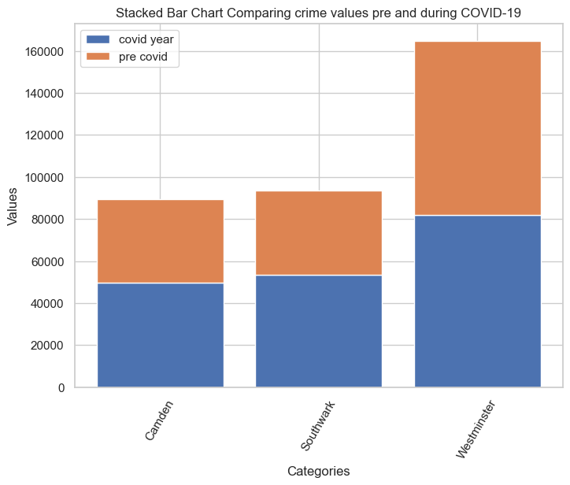

```python
columnscrime = crimecomp.columns
valuescrime = crimecomp.sum()

covcol = covcomp.columns
covval = covcomp.sum()

plt.figure(figsize=(8, 6))

plt.bar(covcol, covval, label='covid year')
plt.bar(columnscrime, valuescrime, bottom=covval, label='pre covid')

plt.xlabel('Categories')
plt.ylabel('Values')
plt.title('Stacked Bar Chart Comparing crime values pre and during COVID-19')
plt.xticks(rotation=60)
plt.legend()
plt.show()
```

```python
# Loading the dataset

crime3 = pd.DataFrame(pd.read_csv("MPS Borough Level Crime (Historical).csv"))
```

```python
crime3.drop(columns=['MinorText','LookUp_BoroughName'])
```

|  | MajorText | 201004 | 201005 | 201006 | 201007 | 201008 | 201009 | 201010 | 201011 | 201012 | ... | 202012 | 202101 | 202102 | 202103 | 202104 | 202105 | 202106 | 202107 | 202108 | 202109 |
| --- | --- | --- | --- | --- | --- | --- | --- | --- | --- | --- | --- | --- | --- | --- | --- | --- | --- | --- | --- | --- | --- |
| 0 | Arson and Criminal Damage | 6 | 5 | 11 | 10 | 6 | 6 | 13 | 13 | 14 | ... | 2 | 4 | 6 | 4 | 6 | 6 | 5 | 4 | 12 | 5 |
| 1 | Arson and Criminal Damage | 208 | 193 | 227 | 220 | 204 | 163 | 199 | 178 | 138 | ... | 110 | 100 | 104 | 80 | 99 | 128 | 141 | 130 | 144 | 111 |
| 2 | Burglary | 49 | 58 | 59 | 47 | 46 | 51 | 52 | 62 | 49 | ... | 24 | 21 | 18 | 14 | 12 | 30 | 24 | 21 | 29 | 27 |
| 3 | Burglary | 118 | 102 | 124 | 137 | 153 | 136 | 116 | 140 | 105 | ... | 91 | 70 | 90 | 71 | 75 | 81 | 66 | 61 | 87 | 62 |
| 4 | Drug Offences | 9 | 6 | 5 | 12 | 9 | 7 | 11 | 11 | 4 | ... | 13 | 12 | 11 | 12 | 9 | 9 | 7 | 6 | 11 | 19 |
| ... | ... | ... | ... | ... | ... | ... | ... | ... | ... | ... | ... | ... | ... | ... | ... | ... | ... | ... | ... | ... | ... |
| 1722 | Vehicle Offences | 231 | 215 | 204 | 213 | 167 | 197 | 197 | 204 | 287 | ... | 238 | 118 | 129 | 150 | 156 | 265 | 218 | 218 | 244 | 267 |
| 1723 | Vehicle Offences | 79 | 54 | 46 | 41 | 55 | 82 | 87 | 53 | 25 | ... | 40 | 53 | 34 | 51 | 39 | 41 | 34 | 56 | 46 | 61 |
| 1724 | Violence Against the Person | 0 | 1 | 0 | 0 | 0 | 0 | 0 | 0 | 0 | ... | 1 | 0 | 1 | 0 | 0 | 1 | 0 | 1 | 2 | 0 |
| 1725 | Violence Against the Person | 271 | 283 | 289 | 328 | 288 | 270 | 319 | 287 | 279 | ... | 198 | 134 | 129 | 174 | 220 | 260 | 317 | 416 | 376 | 325 |
| 1726 | Violence Against the Person | 295 | 322 | 356 | 346 | 312 | 316 | 297 | 280 | 264 | ... | 441 | 355 | 383 | 481 | 506 | 539 | 612 | 690 | 621 | 627 |

1727 rows × 139 columns

```python
# Filtering data for pre COVID-19
crime3.drop(crime3.columns[1:84], axis=1, inplace=True)
```

```python
crime3 = crime3.rename(columns = {'MajorText' : 'Type_of_crime'})

crime3 = crime3.groupby('Type_of_crime', as_index=True).sum()
```

```python
crimepre = pd.pivot_table(crime3, values=['201709','201710','201711','201712','201801','201802','201803','201804','201805','201806','201807','201808','201809','201810','201811','201812','201901','201902','201903','201904','201905','201906','201907','201908','201909','201910','201911','201912'],columns=['Type_of_crime'],aggfunc='sum')
```

```python
crimepre['Date'] = pd.to_datetime(crimepre.index,format='%Y%m').strftime('%b-%Y')
crimepre.set_index('Date', inplace=True)
```

```python
# Filtering data for 2020
crime3post = crime3.filter(regex='2020', axis=1)
```

```python
crimepost = pd.pivot_table(crime3post, values=['202001','202002','202003','202004','202005','202006','202007','202008','202009','202010','202011','202012'],columns=['Type_of_crime'],aggfunc='sum')
```

```python
crimepost['Date'] = pd.to_datetime(crimepost.index,format='%Y%m').strftime('%b-%Y')
crimepost.set_index('Date', inplace=True)
```

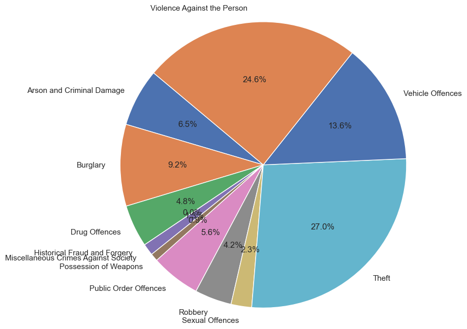

```python
preval = crimepre.sum()
precol = crimepre.columns

# Plotting the pie chart
plt.figure(figsize=(8, 8))
plt.pie(preval, labels=precol, autopct='%1.1f%%', startangle=140)
plt.axis('equal') # ensuring pie chart is plot in a circle
plt.show()
```

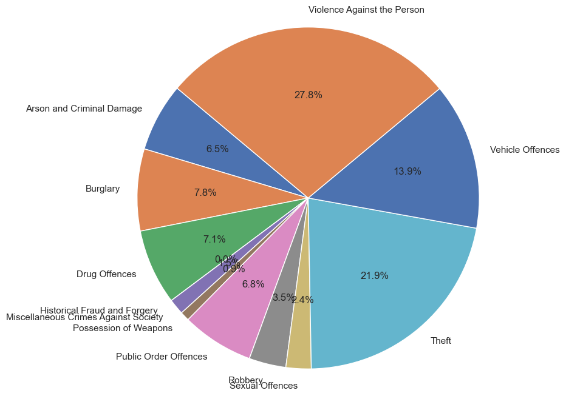

```python
crimeval = crimepost.sum()
crimecol = crimepost.columns

# Plotting the pie chart
plt.figure(figsize=(8, 8))
plt.pie(crimeval, labels=crimecol, autopct='%1.1f%%', startangle=140)
plt.axis('equal')
plt.show()
```

```python
pre = crimepre.iloc[:, [9,10,11]]
post = crimepost.iloc[:, [9,10,11]]
```

```python
post.reset_index()
pre.reset_index()
```

| Type_of_crime | Date | Theft | Vehicle Offences | Violence Against the Person |
| --- | --- | --- | --- | --- |
| 0 | Sep-2017 | 18763 | 8925 | 16403 |
| 1 | Oct-2017 | 19329 | 9287 | 17846 |
| 2 | Nov-2017 | 19481 | 9291 | 16966 |
| 3 | Dec-2017 | 17708 | 8542 | 16356 |
| 4 | Jan-2018 | 17639 | 9474 | 16462 |
| 5 | Feb-2018 | 16333 | 8778 | 14743 |
| 6 | Mar-2018 | 17338 | 8955 | 17213 |
| 7 | Apr-2018 | 17498 | 8932 | 16620 |
| 8 | May-2018 | 18456 | 8883 | 19001 |
| 9 | Jun-2018 | 18323 | 9032 | 18842 |
| 10 | Jul-2018 | 19832 | 9087 | 20245 |
| 11 | Aug-2018 | 18549 | 9243 | 17331 |
| 12 | Sep-2018 | 18173 | 9807 | 17392 |
| 13 | Oct-2018 | 20156 | 10519 | 18026 |
| 14 | Nov-2018 | 20040 | 10536 | 17680 |
| 15 | Dec-2018 | 19542 | 9648 | 17956 |
| 16 | Jan-2019 | 19147 | 10869 | 17436 |
| 17 | Feb-2019 | 19866 | 9684 | 16834 |
| 18 | Mar-2019 | 21526 | 10814 | 18741 |
| 19 | Apr-2019 | 21689 | 10308 | 17548 |
| 20 | May-2019 | 21876 | 10074 | 18898 |
| 21 | Jun-2019 | 21279 | 10066 | 19061 |
| 22 | Jul-2019 | 22914 | 10539 | 20328 |
| 23 | Aug-2019 | 21055 | 10497 | 18652 |
| 24 | Sep-2019 | 20012 | 11633 | 18493 |
| 25 | Oct-2019 | 22370 | 12322 | 18923 |
| 26 | Nov-2019 | 21372 | 11401 | 18923 |
| 27 | Dec-2019 | 20305 | 10988 | 18271 |

To calculate the presentage difference the following formula is used.

Rate of Change= ((Percentage during COVID)-(Percentage pre COVID))/(Percentage pre COVID)×100

Ideally, this would be done by code and attempts have been made but were unsuccesful.

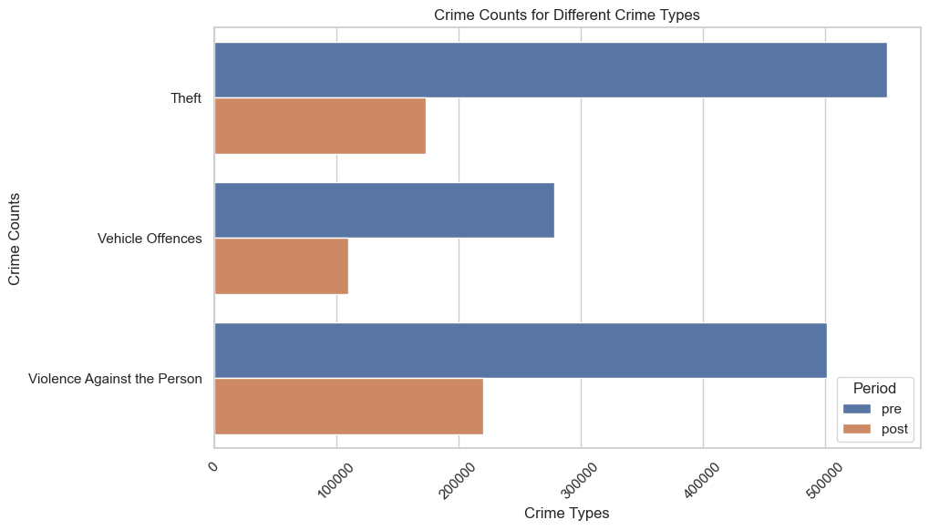

```python
import pandas as pd

sums_pre = pre.sum()
sums_post = post.sum()

# Merging sums into a single DataFrame
combined_sums = pd.concat([sums_pre, sums_post], axis=1)
combined_sums.columns = ['pre', 'post']

combined_sums = combined_sums.reset_index()

# Melting the dataframe for plotting
melted_df = combined_sums.melt(id_vars='Type_of_crime', var_name='Period', value_name='Crime_count')

# Plotting the bar plot
plt.figure(figsize=(10, 6))
sns.barplot(data=melted_df, x='Crime_count', y='Type_of_crime', hue='Period', orient='h')
plt.title('Crime Counts for Different Crime Types')
plt.xlabel('Crime Types')
plt.ylabel('Crime Counts')
plt.xticks(rotation=45)
plt.legend(title='Period')
plt.show()
```

Comparison of recent data to pre COVID-19.

```python
crimepre['Pre']=crimepre.sum(axis=1)
```

```python
pre1 = crimepre.iloc[:, [12]]
```

```python
pre1 = pre1.reset_index()
```

```python
crimepost2 = crimedf1.iloc[40:73]
```

```python
crimepost2['Sum']=crimepost2.sum(axis=1)
```

```python
crimepost22 = crimepost2.iloc[:,[33]]
```

```python
crimepost22 = crimepost22.reset_index()
```

```python
crimepost22['Date'] = pd.to_datetime(crimepost22['Date'], format='%b-%Y')
crimepost22['Date'] = pd.to_datetime(crimepost22['Date'], format='%b-%Y')

# Calculating start and end dates for both DataFrames
start_date_df1 = pre1['Date'].min()
end_date_df1 = pre1['Date'].max()

start_date_df2 = crimepost22['Date'].min()
end_date_df2 = crimepost22['Date'].max()

# Defining a function to scale the dates of crimepost22 to match the range of pre1
def scale_date(date):
    scaled_date = start_date_df1 + ((date - start_date_df2) / (end_date_df2 - start_date_df2)) * (end_date_df1 - start_date_df1)
    return scaled_date

# Applying the scaling function to create 'Scaled_Date' column in crimepost22
crimepost22['Scaled_Date'] = crimepost22['Date'].apply(scale_date)

# Plotting
plt.figure(figsize=(10, 6))

# Ploting pre1
sns.lineplot(x='Date', y='Pre', data=pre1, label='pre')

# Plotting crimepost22 with scaled x-values
sns.lineplot(x='Scaled_Date', y='Sum', data=crimepost22, label='post')


plt.xlabel('Date')
plt.legend()
plt.show()
```

[output not shown]

```python
plt.figure(figsize=(10, 6))
sns.lineplot(x='Date', y='Sum', data=pre1, label='pre')
sns.lineplot(x='Scaled_Date', y='Sum', data=crimepost22, label='post')

# Adjust x-axis limits to zoom into a specific range
# Define the range you want to zoom into (change these dates according to your data)
zoom_start_date = pd.to_datetime('2019-11-01')  # Convert start date to datetime
zoom_end_date = pd.to_datetime('2020-01-01')

# Set x-axis limits for the zoomed-in range
plt.xlim(zoom_start_date, zoom_end_date)

# Set x-axis label to 'Date'
plt.xlabel('Date')
plt.legend()
plt.show()
```

[output not shown]

[output cut: 15 more lines]

[output not shown]

A last minute error was found that doesn't allow for the plots above to appear. However an earlier version of the plot that was supposed to be formed can be seen in the report in the findings section.

Note that the earlier form doesn't have its x axis scaled to the proper timeframe.

Now, regarding the dataset on public opinion.

```python
op = pd.DataFrame(pd.read_csv('public-perception-data.csv'))
```

```python
op['date'] = pd.to_datetime(op['date'], format='%b-%y').dt.strftime('%b-%Y')
```

```python
opinion = op.iloc[175:235]
```

```python
keywords_to_remove = ['Agree the police listen to the concerns of local people','Agree the police can be relied upon to be there when needed','Agree the police treat everyone fairly regardless of who they are','Knows how to contact their local ward officer','Agree the police are dealing with the things that matter to this community','Feels well informed about local police activities over the last 12 months']
# Filtering dataframe to exclude the options not chosen.
opinion1 = opinion[~opinion['measure'].isin(keywords_to_remove)]
```

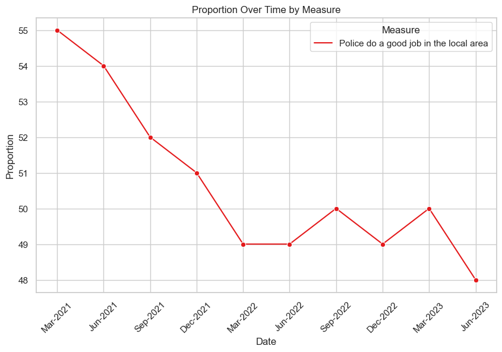

```python
plt.figure(figsize=(10, 6))
sns.lineplot(data=opinion1, x='date', y='proportion', hue='measure', palette='Set1', marker='o')
plt.title('Proportion Over Time by Measure')
plt.xlabel('Date')
plt.ylabel('Proportion')
plt.legend(title='Measure')
plt.xticks(rotation=45)
plt.show()
```

```python
opinion1.set_index('date', inplace=True)
```

```python
opinion2 = opinion1.drop(columns='measure')
```

```python
crimecomp = crimepost22
crimecomp.set_index('Date',inplace=True)
```

```python
timestamps_opinion = opinion1.index

# Filtering 'crimecomp' to match the timestamps present in 'opinion1'
crmatch = crimecomp[crimecomp.index.isin(timestamps_opinion)]
```

```python
crmatch
```

| Borough Date | Sum |
| --- | --- |
| 2021-03-01 | 62763 |
| 2021-06-01 | 69958 |
| 2021-09-01 | 70362 |
| 2021-12-01 | 67430 |
| 2022-03-01 | 73715 |
| 2022-06-01 | 73522 |
| 2022-09-01 | 69709 |
| 2022-12-01 | 69585 |
| 2023-03-01 | 78202 |
| 2023-06-01 | 81536 |

```python
crimee = crmatch.iloc[0:10]
```

```python
crimee
```

| Borough Date | Sum |
| --- | --- |
| 2021-03-01 | 62763 |
| 2021-06-01 | 69958 |
| 2021-09-01 | 70362 |
| 2021-12-01 | 67430 |
| 2022-03-01 | 73715 |
| 2022-06-01 | 73522 |
| 2022-09-01 | 69709 |
| 2022-12-01 | 69585 |
| 2023-03-01 | 78202 |
| 2023-06-01 | 81536 |

```python
opinion2
```

| date | proportion |
| --- | --- |
| Mar-2021 | 55 |
| Jun-2021 | 54 |
| Sep-2021 | 52 |
| Dec-2021 | 51 |
| Mar-2022 | 49 |
| Jun-2022 | 49 |
| Sep-2022 | 50 |
| Dec-2022 | 49 |
| Mar-2023 | 50 |
| Jun-2023 | 48 |

```python
import scipy.stats as stats

# Assuming 'opinion1' contains proportions and 'crimecomp' contains numeric crime counts
statistic, p_value = stats.ttest_ind(opinion2['proportion'], crimee['Sum'])
print(f"T-test statistic: {statistic}, p-value: {p_value}")
```

```
T-test statistic: -42.3243878334402, p-value: 1.778153328459037e-19
```